# Tema 3. Ejercicio obligatorio

Pedro Fernández Rodríguez

29/10/2021

Utilizaremos los datos “trees”. Se trata de un conjunto de datos que consta de 31 observaciones sobre mediciones de la circunferencia, altura y volumen de la madera sobre cerezos negros talados:

- Girth: Diámetro en pulgadas del árbol.
- Height: Altura en pies del árbol.
- Volume: Volumen de la madera en pies cúbicos.

Para acceder a los datos escribimos en R:

```r
# Activamos los datos
data(trees)
```

Se desea estimar un modelo de regresión dque estime el volumen (Volume) en función de la circunferencia del árbol (Girth) y la altura del árbol (Height); para ello:

## Realice un análisis exploratorio y visualice la relación entre las tres variables.

Comenzamos describiendo la relación entre las variables Volume, Girth y Height.

```r
# observamos las primeras 5 observaciones
head(trees)
```

|  | Girth | Height | Volume |
| --- | --- | --- | --- |
| 1 | 8.3 | 70 | 10.3 |
| 2 | 8.6 | 65 | 10.3 |
| 3 | 8.8 | 63 | 10.2 |
| 4 | 10.5 | 72 | 16.4 |
| 5 | 10.7 | 81 | 18.8 |
| 6 | 10.8 | 83 | 19.7 |

```r
# Obtenemos las dimensiones de la base de datos
dim(trees)
```

```
## [1] 31  3
```

Vemos que las 3 variables que vamos a analizar (Volume, Girth y Height) son todas numéricas.

Podemos visualizar la relación entre la respuesta y los predictores mediante 2 diagramas de dispersión. Para ello utilizamos la función ggpairs del paquete GGally.

```r
# Instalamos el paquete GGally en caso de no tenerlo instalado
#install.packages("GGally")

# Activamos el paquete GGally
library(GGally)
```

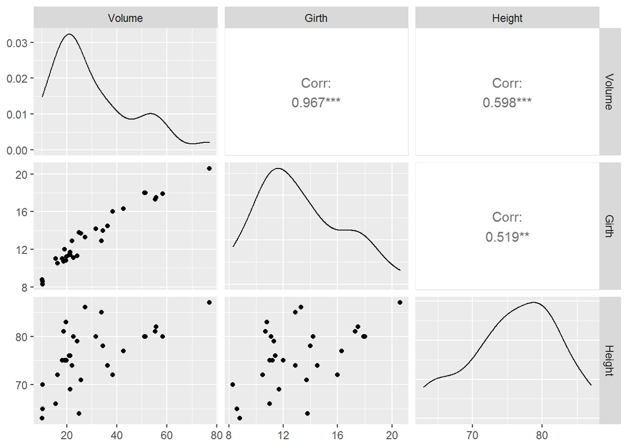

```r
# Graficamos las 3 variables
ggpairs(trees[,c("Volume", "Girth","Height")])
```

Vemos que exsiste una relación positiva entre los tres pares de variables. En caso del par Volume y Girth, la correlación es mayor.

También podemos obtener un gráfico 3D con la nube de puntos mediante la función scatter3D del paquete plot3D.

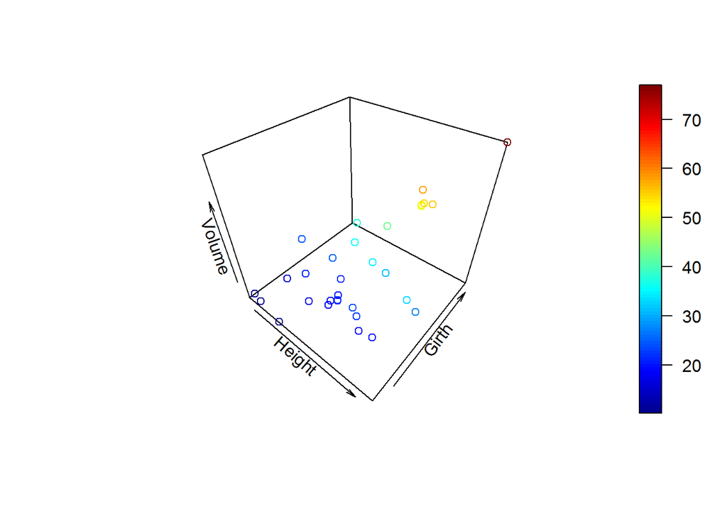

```r
# Instalamos el paquete plot3D en caso de no tenerlo instalado
#install.packages("plot3D")

# Activamos el paquete plot3D
library(plot3D)

# Realizamos el gráfico 3D con las 3 variables que estamos analizando
scatter3D(x=trees$Height,
y=trees$Girth,
z=trees$Volume,
xlab="Height",
ylab="Girth",
zlab="Volume")
```

## Realice un modelo de regresión múltiple por medio de la función lm() solo con efectos principales. Interprete la bondad de ajuste del modelo. Calcule la tasa de error del modelo.

Realizamos un modelo de regresión múltiple por medio de la función lm() para las 3 variables que vamos a analizar (Volume, Girth y Height).

```r
# Ajustamos el modelo de regresión lineal múltiple
model_trees <- lm(Volume~Girth+Height, data= trees)

# Observamos los resultados
summary(model_trees)
```

```
##
## Call:
## lm(formula = Volume ~ Girth + Height, data = trees)
##
## Residuals:
##     Min      1Q  Median      3Q     Max
## -6.4065 -2.6493 -0.2876  2.2003  8.4847
##
## Coefficients:
##             Estimate Std. Error t value Pr(>|t|)
## (Intercept) -57.9877     8.6382  -6.713 2.75e-07 ***
## Girth         4.7082     0.2643  17.816  < 2e-16 ***
## Height        0.3393     0.1302   2.607   0.0145 *
## ---
## Signif. codes:  0 '***' 0.001 '**' 0.01 '*' 0.05 '.' 0.1 ' ' 1
##
## Residual standard error: 3.882 on 28 degrees of freedom
## Multiple R-squared:  0.948,  Adjusted R-squared:  0.9442
## F-statistic:   255 on 2 and 28 DF,  p-value: < 2.2e-16
```

Para interpretar la bondad de ajuste observamos los resultados finales del modelo:

- Prueba de F global: El modelo de regresión predice el volumen de madera significativamente bien (F (2, 28) = 255, p −value < .001).
- El error estándar residual (RSE) es de 3.882 pies cúbicos.
- La tasa de error es

```r
sigma(model_trees)/mean(trees$Volume)
```

```
## [1] 0.1286612
```

- R2: el coeficiente de determinación ajustado (que es el que nos interesa) es R2= .9442, es decir,nuestro modelo (o los 2 predictores considerados) explican el 94.42% de la variabilidad en la respuesta.

## Interprete los coeficientes del modelo.

Obtenemos la tabla de coeficientes:

```r
summary(model_trees)$coefficients
```

```
##                Estimate Std. Error   t value     Pr(>|t|)
## (Intercept) -57.9876589  8.6382259 -6.712913 2.749507e-07
## Girth         4.7081605  0.2642646 17.816084 8.223304e-17
## Height        0.3392512  0.1301512  2.606594 1.449097e-02
```

## Calcule los intervalos de confianza para los coeficientes.

```r
confint(model_trees)
```

```
##                    2.5 %      97.5 %
## (Intercept) -75.68226247 -40.2930554
## Girth         4.16683899   5.2494820
## Height        0.07264863   0.6058538
```

## Calcule la importancia relativa de los predictores.

La función *calc.relimp()* del paquete *relaimpo* calcula la importancia relativa de los predictores con el método **LMG**. Nos da la contribución de cada predictor al R<sup>2</sup> (promediada según el orden en que se ingresan los predictores).

```r
# Instalamos el paquete relaimpo en caso de no tenerlo instalado
#install.packages("relaimpo")

# Activamos el paquete
library(relaimpo)
```

```r
# Calculamos la importancia relativa de los predictores.
crlm <- calc.relimp(model_trees, # objeto con el modelo
type = c("lmg"), # medida utilizada
rela = TRUE) # para sumar 100%

#resultados
crlm
```

```
## Response variable: Volume
## Total response variance: 270.2028
## Analysis based on 31 observations
##
## 2 Regressors:
## Girth Height
## Proportion of variance explained by model: 94.8%
## Metrics are normalized to sum to 100% (rela=TRUE).
##
## Relative importance metrics:
##
##             lmg
## Girth  0.804561
## Height 0.195439
##
## Average coefficients for different model sizes:
##
##              1X       2Xs
## Girth  5.065856 4.7081605
## Height 1.543350 0.3392512
```

Según el método LMG la variable Girth (.804561) tiene mayor importancia relativa en el modelo respecto a Height (.195439).

## Evalué los supuestos del modelo.

Realizamos los gráficos diagnóstico del modelo.

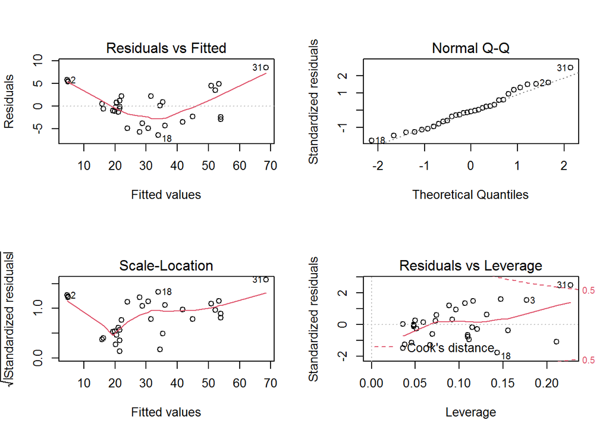

```r
#gráficos diagnóstico del modelo
par(mfrow = c(2,2))
plot(model_trees)
```

Podemos indicar que:

1. Los residuos aumentan en los extremos del rango de valores ajustados con lo cual no se cumpliría el supuesto de homogeneidad de varianza (u Homocedásticidad).
2. ‘Normal Q-Q’. Los residuos parecen seguir una distribución normal, las colas no se apartan demasiado de la diagonal. Lo podemos comprobar con la prueba de Shapiro-Wilk.

```r
# Prueba de normalidad de los residuos del modelo
shapiro.test(model_trees$residuals)
```

```
##
##  Shapiro-Wilk normality test
##
## data:  model_trees$residuals
## W = 0.97431, p-value = 0.644
```

Comprobamos que el p-valor > 0.05 por lo que no descartamos la hipótesis nula, es decir, que los residuos siguen una distribución normal. 3. Lo mismo que en el punto 1. 4. 4. ‘Residuals vs Leverage’. Aunque el valor absoluto de los residuos estandarizados es menor que 3, llama la atención que la observación de mayor diámetro supere la línea de 0.5 de la distancia de Cook.

## Realice un modelo de regresión con efectos de interacción entre los 2 predictores. Evalúe posibles problemas de multicolinealidad y en tal caso centre los predictores.

Ajustamos el modelo de regresión lineal múltiple con interacción:

```r
# Ajustamos un RLM con interacción
model_trees2 <- lm(Volume~Girth*Height, data= trees)
```

Comprobamos si existe multicolinealidad de nuestras variables predictoras.

```r
# Instalamos el paquete car en caso de no tenerlo instalado
#install.packages("car")

# Activamos el paquete
library(car)
```

```r
# Multicolinealidad: VIF
vif(model_trees2)
```

```
##        Girth       Height Girth:Height
##    148.66145     15.93884    210.97302
```

Tenemos problemas de multicolinealidad, los V IF son > 5, esto ocurre porque las variables no están centradas y hemos incluido un término de interacción.

Vamos a centrar las variables para eliminar los problemas de multicolinealidad.

```r
# Centramos la variable Girth
Girth2<-scale(trees$Girth,
center=TRUE,
scale=FALSE)

# Centramos la variable Height
Height2<-scale(trees$Height,
center=TRUE,
scale=FALSE)

# Volvemos a ajustar un RLM con interacción con las variables centradas
model_trees3 <- lm(trees$Volume ~ Girth2*Height2)
```

Volvemos a calcular el VIF.

```r
vif(model_trees3)
```

```
##         Girth2        Height2 Girth2:Height2
##       1.513180       1.487784       1.126849
```

Ya no tenemos problemas de multicolinealidad.

A continuación, evaluamos la significación de cada término del modelo.

```r
Anova(model_trees3)
```

|  | Sum Sq | Df | F value | Pr(>F) |
| --- | --- | --- | --- | --- |
| Girth2 | 4782.9736 | 1 | 651.96497 | 1.922660e-20 |
| Height2 | 102.3812 | 1 | 13.95553 | 8.866800e-04 |
| Girth2:Height2 | 223.8428 | 1 | 30.51191 | 7.484103e-06 |
| Residuals | 198.0786 | 27 | NA | NA |

Vemos que la interacción es significativa (F (1, 27) = 30.51191, p < .001) y por tanto debe incluirse en el modelo final.

## Interprete los coeficientes del modelo.

Observamos la tabla de coeficientes e interpretamos:

```r
summary(model_trees3)
```

```
##
## Call:
## lm(formula = trees$Volume ~ Girth2 * Height2)
##
## Residuals:
##     Min      1Q  Median      3Q     Max
## -6.5821 -1.0673  0.3026  1.5641  4.6649
##
## Coefficients:
##                Estimate Std. Error t value Pr(>|t|)
## (Intercept)    28.81791    0.54466  52.910  < 2e-16 ***
## Girth2          4.37789    0.19384  22.585  < 2e-16 ***
## Height2         0.48687    0.09466   5.143 2.07e-05 ***
## Girth2:Height2  0.13465    0.02438   5.524 7.48e-06 ***
## ---
## Signif. codes:  0 '***' 0.001 '**' 0.01 '*' 0.05 '.' 0.1 ' ' 1
##
## Residual standard error: 2.709 on 27 degrees of freedom
## Multiple R-squared:  0.9756, Adjusted R-squared:  0.9728
## F-statistic: 359.3 on 3 and 27 DF,  p-value: < 2.2e-16
```

Como hemos centrado previamente las variables, interpretamos la interacción de la siguiente manera:

- El efecto de la circunferencia (Girth2) sobre el volumen de madera (Volume) aumenta en 0.13465 pies cúbicos por cada pie que aumenta la altura (Height2).

El modelo final es:

$$\begin{aligned}
\operatorname{{Volume}} &= 28.81791 + 4.37789 ∗\operatorname{\overline{Girth}} + 0.48687 ∗ \operatorname{\overline{Height}} + 0.13465*\operatorname{\overline{Girth}} : \operatorname{\overline{Height}}
\end{aligned}$$